#### Adding Trend and Season to Find the Lowest-Forecast-RMSE Model

In my previous post, I experimented with various model structures on various lags. All of the previous models include a constant and trend. Since Employment, Inflation, IPI exit trend, and theoritically all 4 variables could have seasonal properities. In this post, I plan to add both trend and season=12 in the models. The RMSEs show a great improvement.  
Although 3 of the series are seasonally adjusted, the outputs show adding season generally lowers the forecast RMSE.

#### 1. Compare the Forecast RMSEs from Various Model Structures with Various Lags.

1. The Forecast RMSEs when Employment and Inflation as endogenous variables, without any exogenous variables, with trend and season.

   ```
             Lag1    Lag2    Lag3   Lag4    Lag5    Lag6    Lag7
   Employment 6323.31 6858.26 7226.04 7899.5 8038.54 8265.58 8478.85
   Inflation     2.94    3.03    3.04    3.0    2.97    2.97    2.96
   Sum        6326.25 6861.29 7229.08 7902.5 8041.51 8268.55 8481.81
             Lag8   Lag9   Lag10
   Employment 8439.02 8510.2 8420.91
   Inflation     2.92    2.8    2.76
   Sum        8441.94 8513.0 8423.67
   ```

2. The Forecast RMSEs when Employment and Inflation as endogenous variables, IPI as exogenous variables, with trend and season.

   ```
             Lag1    Lag2    Lag3    Lag4    Lag5    Lag6    Lag7
   Employment 7235.01 7546.12 7376.81 7353.33 6731.40 6428.63 6101.47
   Inflation     3.91    4.06    4.18    4.09    4.07    4.01    3.84
   Sum        7238.92 7550.18 7380.99 7357.42 6735.47 6432.64 6105.31
             Lag8    Lag9   Lag10
   Employment 5918.67 5800.08 5256.07
   Inflation     3.73    3.36    3.20
   Sum        5922.40 5803.44 5259.27
   ```

3. The Forecast RMSEs when Employment and Inflation as endogenous variables, Treasury as exogenous variables, with trend and season.

   ```
             Lag1    Lag2    Lag3    Lag4    Lag5    Lag6    Lag7
   Employment 7785.41 8225.12 8452.89 8638.03 8110.83 7869.63 7543.12
   Inflation     5.29    5.41    5.40    5.17    5.07    5.04    4.87
   Sum        7790.70 8230.53 8458.29 8643.20 8115.90 7874.67 7547.99
             Lag8    Lag9   Lag10
   Employment 7315.72 7370.09 6765.56
   Inflation     4.75    4.30    4.10
   Sum        7320.47 7374.39 6769.66
   ```

4. The Forecast RMSEs when Employment and Inflation as endogenous variables, IPI and Treasury as exogenous variables, with trend and season.

   ```
             Lag1    Lag2    Lag3    Lag4    Lag5    Lag6    Lag7
   Employment 7660.10 8116.41 8275.02 8161.94 7182.07 6651.14 6069.48
   Inflation     5.46    5.58    5.46    5.16    4.90    4.78    4.52
   Sum        7665.56 8121.99 8280.48 8167.10 7186.97 6655.92 6074.00
             Lag8    Lag9   Lag10
   Employment 5809.19 5783.02 5036.68
   Inflation     4.37    3.97    3.68
   Sum        5813.56 5786.99 5040.36
   ```

5. The Forecast RMSEs when all four variables as endogenous variables, with trend and season.

   ```
             Lag1    Lag2    Lag3    Lag4    Lag5    Lag6    Lag7
   Employment 6333.63 5293.82 3772.65 3416.75 3660.39 3990.76 4368.22
   Inflation     4.37    6.09    6.45    6.42    6.43    6.39    6.10
   Sum        6338.00 5299.91 3779.10 3423.17 3666.82 3997.15 4374.32
             Lag8    Lag9   Lag10
   Employment 4478.82 4556.57 4753.23
   Inflation     5.73    5.28    5.03
   Sum        4484.55 4561.85 4758.26
   ```

#### 2. The Model with the Lowest Forecast RMSE

The lowest forecast RMSE happens when all 4 variables are endogenous variables, with trend and season=12, and the lag=4.

```
RMSE          Lag4
Employment 3416.75
Inflation     6.42
Sum        3423.17
```

```
VAR Estimation Results, Only Showing Employment and Inflation Equations
=======================

Estimated coefficients for equation Employment:
===============================================
Employment = Employment.l1 + Inflation.l1 + IPI.l1 + Treasury.l1 + Employment.l2 + Inflation.l2 + IPI.l2 + Treasury.l2 + Employment.l3 + Inflation.l3 + IPI.l3 + Treasury.l3 + Employment.l4 + Inflation.l4 + IPI.l4 + Treasury.l4 + trend + sd1 + sd2 + sd3 + sd4 + sd5 + sd6 + sd7 + sd8 + sd9 + sd10 + sd…

Employment.l1  Inflation.l1        IPI.l1   Treasury.l1 Employment.l2
   1.11006918  -62.55623259   70.69572330   38.11919514    0.20215879
 Inflation.l2        IPI.l2   Treasury.l2 Employment.l3  Inflation.l3
  47.07509610  -70.47396209   -8.56667746   -0.06605721  -25.85503896
       IPI.l3   Treasury.l3 Employment.l4  Inflation.l4        IPI.l4
  11.78995291  -58.34919816   -0.24194750   39.08015364  -17.32868216
  Treasury.l4         trend           sd1           sd2           sd3
  25.45262088    0.87699000  -15.48642957   12.88634317   14.35384926
          sd4           sd5           sd6           sd7           sd8
  -5.58223264   -6.41880667  -19.25521473   -9.90234896  -20.49676024
          sd9          sd10          sd11
  23.72076865   13.16422615   20.85681628


Estimated coefficients for equation Inflation:
==============================================
Call:
Inflation = Employment.l1 + Inflation.l1 + IPI.l1 + Treasury.l1 + Employment.l2 + Inflation.l2 + IPI.l2 + Treasury.l2 + Employment.l3 + Inflation.l3 + IPI.l3 + Treasury.l3 + Employment.l4 + Inflation.l4 + IPI.l4 + Treasury.l4 + trend + sd1 + sd2 + sd3 + sd4 + sd5 + sd6 + sd7 + sd8 + sd9 + sd10 + sd1…

Employment.l1  Inflation.l1        IPI.l1   Treasury.l1 Employment.l2
-3.791046e-05  1.404312e+00  8.250601e-03  1.236965e-01  1.448566e-04
 Inflation.l2        IPI.l2   Treasury.l2 Employment.l3  Inflation.l3
-5.477334e-01 -3.433496e-02 -8.833672e-02 -1.191263e-04  2.945478e-01
       IPI.l3   Treasury.l3 Employment.l4  Inflation.l4        IPI.l4
 1.459452e-02  2.026665e-02  1.184878e-05 -1.552179e-01  1.213952e-02
  Treasury.l4         trend           sd1           sd2           sd3
-3.912523e-02  1.750030e-03  1.278400e-01  5.857260e-03  1.125805e-02
          sd4           sd5           sd6           sd7           sd8
 1.911923e-02  1.599518e-02  7.256392e-02  4.701340e-03  3.855840e-02
          sd9          sd10          sd11
 7.069794e-02  2.753972e-02  3.340966e-02
```

#### 3. Analyze the Forecast Error of the Best Model

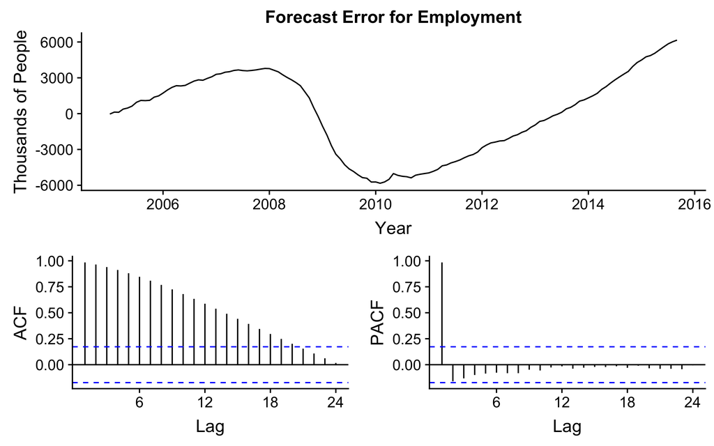

Employment forecast error doesn’t pass the ADF test or the Ljung-Box test up to 24 lags. The correlogram suggests an AR(1) effect.

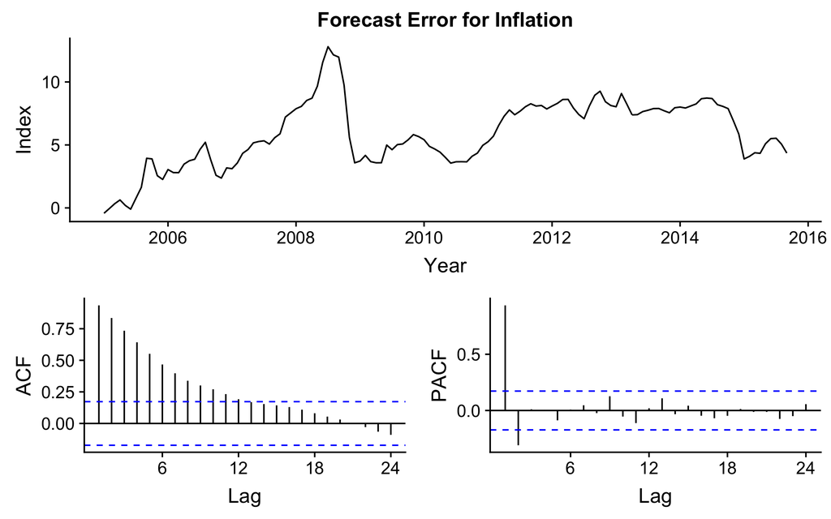

Inflation forecast error doesn’t pass the ADF test or the Ljung-Box test up to 24 lags. The correlogram suggests an AR(2) effect.

Next, I can experiment with variance decomposition and inpulse reponses for the models.

rmarkdown::render(“U5P2.rmd”)